# Practical Machine Learning Course Project

Sanchit Sharma

13 December 2017

## Introduction

Using devices such as Jawbone Up, Nike FuelBand, and Fitbit it is now possible to collect a large amount of data about personal activity relatively inexpensively. These type of devices are part of the quantified self movement - a group of enthusiasts who take measurements about themselves regularly to improve their health, to find patterns in their behavior, or because they are tech geeks. One thing that people regularly do is quantify how much of a particular activity they do, but they rarely quantify how well they do it.

In this project, our goal will be to use data from accelerometers on the belt, forearm, arm, and dumbell of 6 participants. They were asked to perform barbell lifts correctly and incorrectly in 5 different ways. The goal of this project is to predict the manner in which they did the exercise.

## Loading required packages

```r
library(caret)
```

```r
library(rpart)
library(rpart.plot)
library(RColorBrewer)
library(rattle)
library(randomForest)
```

## Load training and testing data

```r
#loading the training data
download.file("https://d396qusza40orc.cloudfront.net/predmachlearn/pml-training.csv", destfile = "pml-training.csv")

#loading the testing data
download.file("https://d396qusza40orc.cloudfront.net/predmachlearn/pml-testing.csv", destfile = "pml-testing.csv")

#Read the training data and replace empty values by NA
trainingData <- read.csv("pml-training.csv", sep=",", header=TRUE, na.strings = c("NA","",'#DIV/0!'))
testingData <- read.csv("pml-testing.csv", sep=",", header=TRUE, na.strings = c("NA","",'#DIV/0!'))
```

## Looking at the data

```r
#structure of training data
str(trainingData)
```

```
## 'data.frame':    19622 obs. of  160 variables:
##  $ X                       : int  1 2 3 4 5 6 7 8 9 10 ...
##  $ user_name               : Factor w/ 6 levels "adelmo","carlitos",..: 2 2 2 2 2 2 2 2 2 2 ...
##  $ raw_timestamp_part_1    : int  1323084231 1323084231 1323084231 1323084232 1323084232 1323084232 1323084232 1323084232 1323084232 1323084232 ...
##  $ raw_timestamp_part_2    : int  788290 808298 820366 120339 196328 304277 368296 440390 484323 484434 ...
##  $ cvtd_timestamp          : Factor w/ 20 levels "02/12/2011 13:32",..: 9 9 9 9 9 9 9 9 9 9 ...
##  $ new_window              : Factor w/ 2 levels "no","yes": 1 1 1 1 1 1 1 1 1 1 ...
##  $ num_window              : int  11 11 11 12 12 12 12 12 12 12 ...
##  $ roll_belt               : num  1.41 1.41 1.42 1.48 1.48 1.45 1.42 1.42 1.43 1.45 ...
##  $ pitch_belt              : num  8.07 8.07 8.07 8.05 8.07 8.06 8.09 8.13 8.16 8.17 ...
##  $ yaw_belt                : num  -94.4 -94.4 -94.4 -94.4 -94.4 -94.4 -94.4 -94.4 -94.4 -94.4 ...
##  $ total_accel_belt        : int  3 3 3 3 3 3 3 3 3 3 ...
##  $ kurtosis_roll_belt      : num  NA NA NA NA NA NA NA NA NA NA ...
##  $ kurtosis_picth_belt     : num  NA NA NA NA NA NA NA NA NA NA ...
##  $ kurtosis_yaw_belt       : logi  NA NA NA NA NA NA ...
```

[output cut: 86 more lines]

```r
#structure of testing data
str(testingData)
```

```
## 'data.frame':    20 obs. of  160 variables:
##  $ X                       : int  1 2 3 4 5 6 7 8 9 10 ...
##  $ user_name               : Factor w/ 6 levels "adelmo","carlitos",..: 6 5 5 1 4 5 5 5 2 3 ...
##  $ raw_timestamp_part_1    : int  1323095002 1322673067 1322673075 1322832789 1322489635 1322673149 1322673128 1322673076 1323084240 1322837822 ...
##  $ raw_timestamp_part_2    : int  868349 778725 342967 560311 814776 510661 766645 54671 916313 384285 ...
##  $ cvtd_timestamp          : Factor w/ 11 levels "02/12/2011 13:33",..: 5 10 10 1 6 11 11 10 3 2 ...
##  $ new_window              : Factor w/ 1 level "no": 1 1 1 1 1 1 1 1 1 1 ...
##  $ num_window              : int  74 431 439 194 235 504 485 440 323 664 ...
##  $ roll_belt               : num  123 1.02 0.87 125 1.35 -5.92 1.2 0.43 0.93 114 ...
##  $ pitch_belt              : num  27 4.87 1.82 -41.6 3.33 1.59 4.44 4.15 6.72 22.4 ...
##  $ yaw_belt                : num  -4.75 -88.9 -88.5 162 -88.6 -87.7 -87.3 -88.5 -93.7 -13.1 ...
##  $ total_accel_belt        : int  20 4 5 17 3 4 4 4 4 18 ...
##  $ kurtosis_roll_belt      : logi  NA NA NA NA NA NA ...
##  $ kurtosis_picth_belt     : logi  NA NA NA NA NA NA ...
##  $ kurtosis_yaw_belt       : logi  NA NA NA NA NA NA ...
```

[output cut: 86 more lines]

Our data consists of 19622 values of 160 variables.

## Cleaning the data

We partition our training data into two

```r
partTrain <- createDataPartition(trainingData$classe, p=0.6, list=FALSE)
myTrainData <- trainingData[partTrain, ]
myTestData <- trainingData[-partTrain, ]
dim(myTrainData); dim(myTestData)
```

```
## [1] 11776   160
```

```
## [1] 7846  160
```

```r
#Remove zero variance variables
novar <- nearZeroVar(myTrainData, saveMetrics=TRUE)
myTrainData <- myTrainData[,novar$nzv==FALSE]

novar <- nearZeroVar(myTestData, saveMetrics=TRUE)
myTestData <- myTestData[,novar$nzv==FALSE]

#Remove the first column of the myTrainData data set
myTrainData <- myTrainData[c(-1)]

#Clean variables with more than 60% missing values
trainData <- myTrainData
for(i in 1:length(myTrainData)) {
    if( sum( is.na( myTrainData[, i] ) ) /nrow(myTrainData) >= .7) {
        for(j in 1:length(trainData)) {
            if( length( grep(names(myTrainData[i]), names(trainData)[j]) ) == 1)  {
                trainData <- trainData[ , -j]
            }
        }
    }
}

# Set back to the original variable name
myTrainData <- trainData
rm(trainData)

#Transform the myTestData and testingData data sets
cleanData1 <- colnames(myTrainData)
cleanData2 <- colnames(myTrainData[, -58])  # remove the classe column
myTestData <- myTestData[cleanData1]         # allow only variables in myTestData that are also in myTrainData
testingData <- testingData[cleanData2]             # allow only variables in testingData that are also in myTrainData

dim(myTestData)
```

```
## [1] 7846   58
```

```r
#Coerce the data into the same type
for (i in 1:length(testingData) ) {
  for(j in 1:length(myTrainData)) {
    if( length( grep(names(myTrainData[i]), names(testingData)[j]) ) == 1)  {
      class(testingData[j]) <- class(myTrainData[i])
    }
  }
}

# To get the same class between testing and myTraining
testingData <- rbind(myTrainData[2, -58] , testingData)
testingData <- testingData[-1,]
```

## Prediction with decision trees

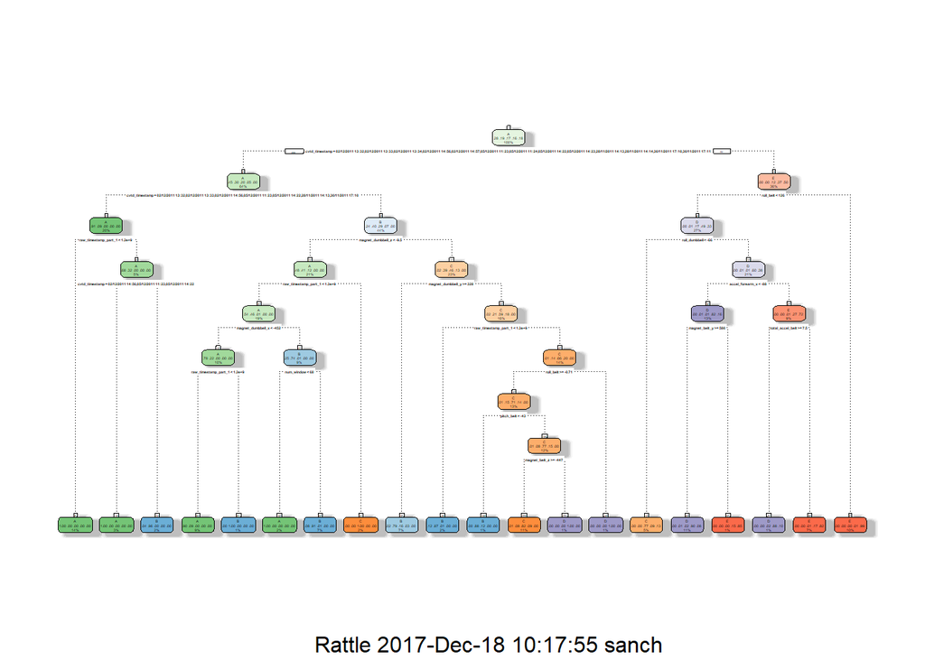

```r
set.seed(3)
dtmodel <- rpart(classe ~ ., data=myTrainData, method="class")
fancyRpartPlot(dtmodel)
```

```r
predictionsdt <- predict(dtmodel, myTestData, type = "class")
cmtree <- confusionMatrix(predictionsdt, myTestData$classe)
cmtree
```

```
## Confusion Matrix and Statistics
##
##           Reference
## Prediction    A    B    C    D    E
##          A 2142   70    8    0    0
##          B   85 1368  126    8    0
##          C    5   70 1212  103   57
##          D    0   10   15 1039   95
##          E    0    0    7  136 1290
##
## Overall Statistics
##
##                Accuracy : 0.8987
##                  95% CI : (0.8918, 0.9053)
##     No Information Rate : 0.2845
##     P-Value [Acc > NIR] : < 2.2e-16
##
##                   Kappa : 0.8718
##  Mcnemar's Test P-Value : NA
##
## Statistics by Class:
##
##                      Class: A Class: B Class: C Class: D Class: E
## Sensitivity            0.9597   0.9012   0.8860   0.8079   0.8946
## Specificity            0.9861   0.9654   0.9637   0.9817   0.9777
## Pos Pred Value         0.9649   0.8620   0.8376   0.8965   0.9002
## Neg Pred Value         0.9840   0.9760   0.9756   0.9631   0.9763
## Prevalence             0.2845   0.1935   0.1744   0.1639   0.1838
## Detection Rate         0.2730   0.1744   0.1545   0.1324   0.1644
## Detection Prevalence   0.2829   0.2023   0.1844   0.1477   0.1826
## Balanced Accuracy      0.9729   0.9333   0.9248   0.8948   0.9361
```

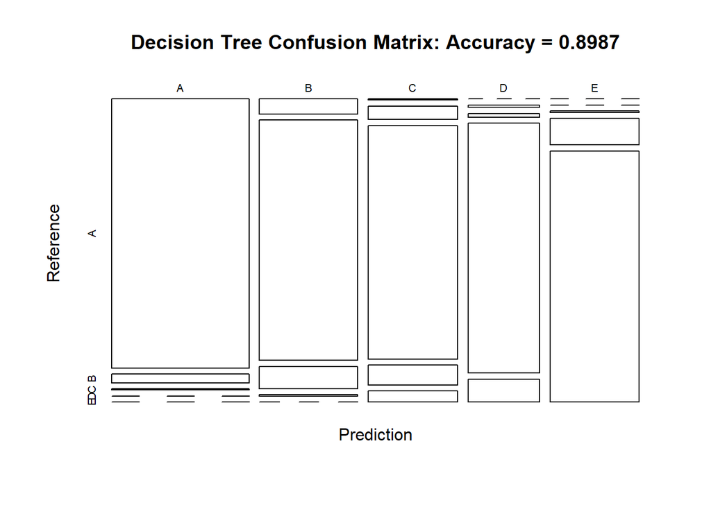

```r
plot(cmtree$table, col = cmtree$byClass, main = paste("Decision Tree Confusion Matrix: Accuracy =", round(cmtree$overall['Accuracy'], 4)))
```

## Prediction using Random Forest

```r
set.seed(1)
rfmodel <- randomForest(classe ~ ., data=myTrainData)
prediction1 <- predict(rfmodel, myTestData, type = "class")
cm <- confusionMatrix(prediction1, myTestData$classe)
cm
```

```
## Confusion Matrix and Statistics
##
##           Reference
## Prediction    A    B    C    D    E
##          A 2232    0    0    0    0
##          B    0 1518    0    0    0
##          C    0    0 1367    2    0
##          D    0    0    1 1284    3
##          E    0    0    0    0 1439
##
## Overall Statistics
##
##                Accuracy : 0.9992
##                  95% CI : (0.9983, 0.9997)
##     No Information Rate : 0.2845
##     P-Value [Acc > NIR] : < 2.2e-16
##
##                   Kappa : 0.999
##  Mcnemar's Test P-Value : NA
##
## Statistics by Class:
##
##                      Class: A Class: B Class: C Class: D Class: E
## Sensitivity            1.0000   1.0000   0.9993   0.9984   0.9979
## Specificity            1.0000   1.0000   0.9997   0.9994   1.0000
## Pos Pred Value         1.0000   1.0000   0.9985   0.9969   1.0000
## Neg Pred Value         1.0000   1.0000   0.9998   0.9997   0.9995
## Prevalence             0.2845   0.1935   0.1744   0.1639   0.1838
## Detection Rate         0.2845   0.1935   0.1742   0.1637   0.1834
## Detection Prevalence   0.2845   0.1935   0.1745   0.1642   0.1834
## Balanced Accuracy      1.0000   1.0000   0.9995   0.9989   0.9990
```

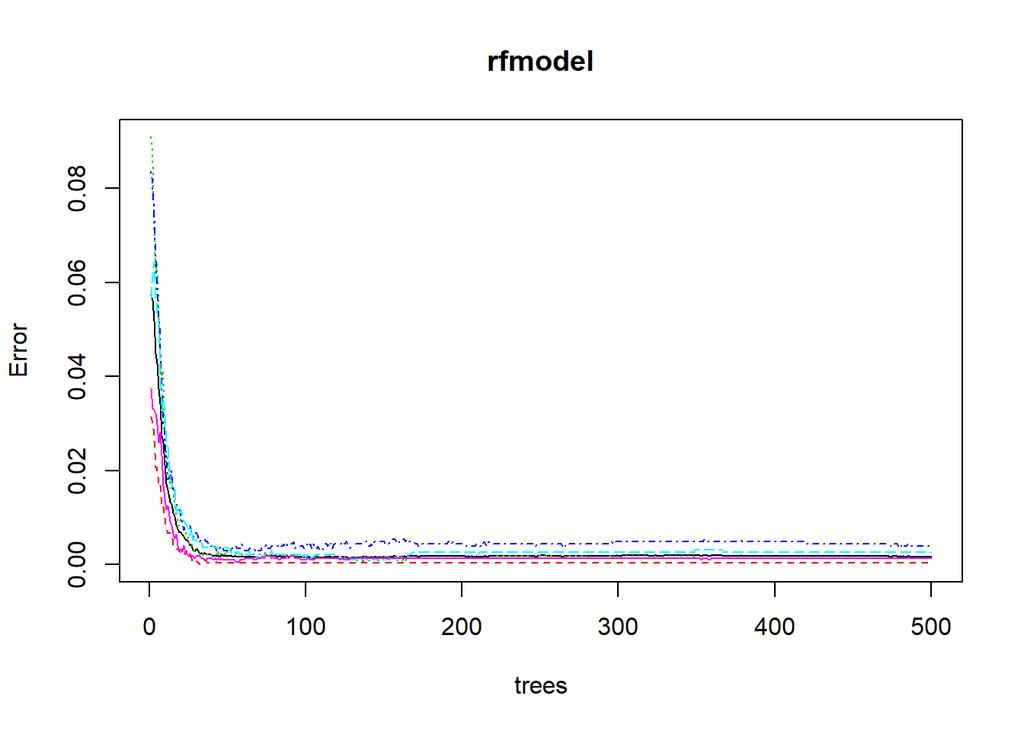

```r
plot(rfmodel)
```

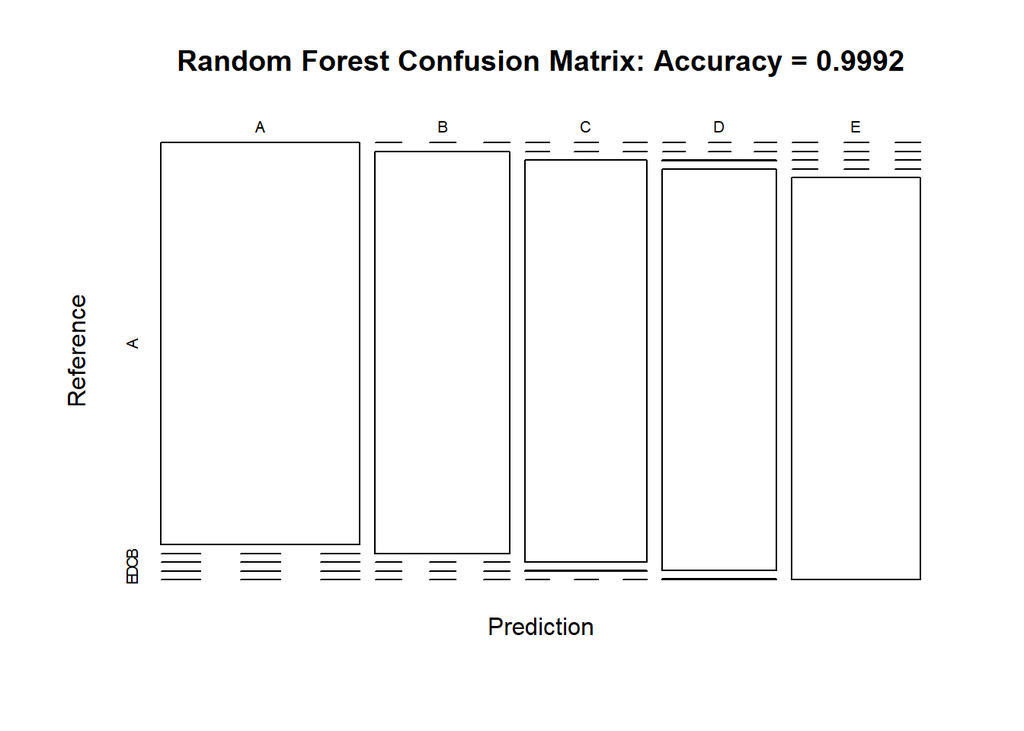

```r
plot(cm$table, col = cmtree$byClass, main = paste("Random Forest Confusion Matrix: Accuracy =", round(cm$overall['Accuracy'], 4)))
```

## Prediction with generalization booster

```r
set.seed(2)
fitControl <- trainControl(method = "repeatedcv",
                           number = 5,
                           repeats = 1)

gbmmodel <- train(classe ~ ., data=myTrainData, method = "gbm",
                 trControl = fitControl,
                 verbose = FALSE)


gbmFinModel <- gbmmodel$finalModel

gbmPrediction <- predict(gbmmodel, newdata=myTestData)
gbmAccuracy <- confusionMatrix(gbmPrediction, myTestData$classe)
gbmAccuracy
```

```
## Confusion Matrix and Statistics
##
##           Reference
## Prediction    A    B    C    D    E
##          A 2232    3    0    0    0
##          B    0 1511    0    0    0
##          C    0    3 1360    2    0
##          D    0    1    8 1282    6
##          E    0    0    0    2 1436
##
## Overall Statistics
##
##                Accuracy : 0.9968
##                  95% CI : (0.9953, 0.9979)
##     No Information Rate : 0.2845
##     P-Value [Acc > NIR] : < 2.2e-16
##
##                   Kappa : 0.996
##  Mcnemar's Test P-Value : NA
##
## Statistics by Class:
##
##                      Class: A Class: B Class: C Class: D Class: E
## Sensitivity            1.0000   0.9954   0.9942   0.9969   0.9958
## Specificity            0.9995   1.0000   0.9992   0.9977   0.9997
## Pos Pred Value         0.9987   1.0000   0.9963   0.9884   0.9986
## Neg Pred Value         1.0000   0.9989   0.9988   0.9994   0.9991
## Prevalence             0.2845   0.1935   0.1744   0.1639   0.1838
## Detection Rate         0.2845   0.1926   0.1733   0.1634   0.1830
## Detection Prevalence   0.2849   0.1926   0.1740   0.1653   0.1833
## Balanced Accuracy      0.9997   0.9977   0.9967   0.9973   0.9978
```

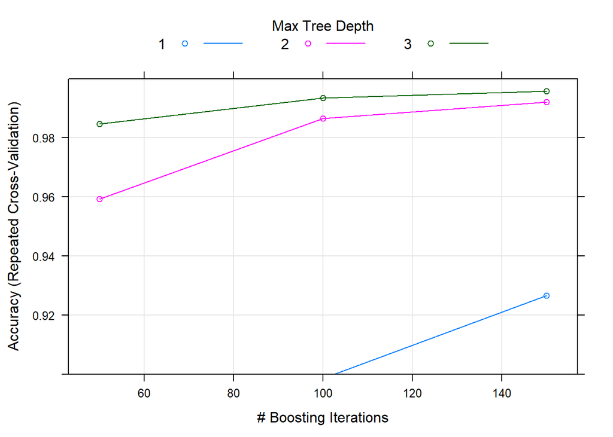

```r
plot(gbmmodel, ylim=c(0.9, 1))
```

## Predicting results on test data

```r
prediction2 <- predict(rfmodel, testingData, type = "class")
prediction2
```

```
##  1 21  3  4  5  6  7  8  9 10 11 12 13 14 15 16 17 18 19 20
##  B  A  B  A  A  E  D  B  A  A  B  C  B  A  E  E  A  B  B  B
## Levels: A B C D E
```